# Appendix 5

Callaghan et al.

October 12, 2017

# R Tutorial to perform analysis on eBird data from an urban greenspace

This document accompanies the Callaghan et al. article titled **Assessing the reliability of avian biodiversity measures of urban greenspaces using eBird citizen science data** in Avian Conservation and Ecology, and is meant to provide an overview for managers, conservationists, and urban planners who wish to use eBird data at a local site.

## Step 1: Download and prepare data for analysis

eBird data can be downloaded from http://ebird.org/ebird/data/download.

First, you need to request access. After access has been granted, you should download the appropriate data at the smallest possible spatial scale (i.e., county, state, or country) where the chosen hotspot is located, and then subset to the interested greenspace. This can sometimes be done in Excel, if the dataset is small enough.

For the purposes of this tutorial, we chose to investigate Beuna Vista Park, located in San Francisco, California. We have already created a dataset that is only for that site, which is also provided.

### Step 1.1: Load necessary packages for analysis

```r
library(readr)
library(dplyr)
library(ggplot2)
library(vegan)
library(reshape2)
library(data.table)
library(tidyr)
```

### Step 1.2: Set working directory

```r
setwd()
```

### Step 1.3: Read eBird data in

We use the `read_csv` function from the `readr` package to read in data

```r
BV <- read_csv("BV.csv")
```

### Step 1.4: Massage data and choose best quality data based on our predefined filters

```r
# Format Date
BV$OBSERVATION_DATE <- as.Date(BV$OBSERVATION_DATE, format = "%Y-%m-%d")

# add year to the dataframe
BV$YEAR <- year(BV$OBSERVATION_DATE)

# add all the columns needed for the analysis (that don't vary within
# checklist)
sampling_event_info <- BV %>% select(SAMPLING_EVENT_IDENTIFIER, LOCALITY, LOCALITY_ID,
    OBSERVATION_DATE, PROTOCOL_TYPE, ALL_SPECIES_REPORTED, EFFORT_DISTANCE_KM,
    EFFORT_AREA_HA, DURATION_MINUTES, YEAR, GROUP_IDENTIFIER, LATITUDE, LONGITUDE) %>%
    distinct()


# Counts how many 'x's per checklist
X_missing <- BV %>% group_by(SAMPLING_EVENT_IDENTIFIER) %>% summarise(number_X = sum(OBSERVATION_COUNT ==
    "X"))


# accounts for the instance in which people submit the same species both at
# the species and subspecies level also makes it so only 'species' and
# 'issf' category are included in analysis
BV_clean <- BV %>% filter(CATEGORY %in% c("species", "issf")) %>% group_by(SAMPLING_EVENT_IDENTIFIER,
    COMMON_NAME) %>% summarise(COUNT_SPP = sum(as.numeric(as.character(OBSERVATION_COUNT)))) %>%
    rename(OBSERVATION_COUNT = COUNT_SPP) %>% inner_join(., sampling_event_info,
    by = "SAMPLING_EVENT_IDENTIFIER") %>% inner_join(., X_missing, by = "SAMPLING_EVENT_IDENTIFIER")

################################################## apply some basic criteria to filter by #####

# apply some filtering criteria
analysis_data <- BV_clean %>% ## filter for only complete checklists
filter(ALL_SPECIES_REPORTED == 1) %>% ## only using stationary, traveling, and exhaustive area type checklists
filter(PROTOCOL_TYPE %in% c("eBird - Exhaustive Area Count", "eBird - Stationary Count",
    "eBird - Traveling Count")) %>% ## Get rid of any checklists that had a single X
filter(number_X == 0) %>% group_by(SAMPLING_EVENT_IDENTIFIER) %>% summarise(Species_Richness = length(unique(COMMON_NAME)),
    Species_Diversity = diversity(OBSERVATION_COUNT), Species_Abundance = sum(OBSERVATION_COUNT,
        na.rm = TRUE), Minutes = mean(DURATION_MINUTES, na.rm = TRUE), Distance_km = mean(EFFORT_DISTANCE_KM,
        na.rm = TRUE), Area_ha = mean(EFFORT_AREA_HA, na.rm = TRUE)) %>% inner_join(BV_clean,
    ., by = "SAMPLING_EVENT_IDENTIFIER") %>% ## Filter between 2010 and 2016
filter(YEAR >= 2010 & YEAR <= 2016)


############################################################################## filtering out group_identifier data to eliminate 'duplicated' checklists
############################################################################## ##

# first select the group_identifiers and associated checklists
duplicated <- analysis_data %>% drop_na(GROUP_IDENTIFIER) %>% select(GROUP_IDENTIFIER,
    SAMPLING_EVENT_IDENTIFIER) %>% distinct(.keep_all = TRUE) %>% group_by(GROUP_IDENTIFIER) %>%
    # randomly sample one checklist for each group_identifier
sample_n(., 1) %>% .$SAMPLING_EVENT_IDENTIFIER

duplicated_data <- analysis_data %>% filter(SAMPLING_EVENT_IDENTIFIER %in% duplicated)

## now, append the selected checklists for each group_identifier with the non
## group_identifier checklists from the data
analysis_data <- analysis_data %>% filter(!grepl("G", GROUP_IDENTIFIER)) %>%
    bind_rows(., duplicated_data)


######################################################### apply distance and duration caps ###########
analysis_data <- analysis_data %>% filter(DURATION_MINUTES >= 5 & DURATION_MINUTES <=
    240) %>% filter(EFFORT_DISTANCE_KM <= 10)


## rename analysis_data to signify it is the 'complete' checklist usage
analysis_data.all <- analysis_data


###################################################################### get rid of species which did not occur on >95% of checklists ####

## Exlude the species that rarely occur
checklists_hotspots <- analysis_data.all %>% group_by(LOCALITY_ID) %>% summarise(total_checklists = length(unique(SAMPLING_EVENT_IDENTIFIER)))

## create a dataframe which removes the species that are on <=5% of
## checklists in a hotspot
analysis_data.95 <- analysis_data.all %>% group_by(LOCALITY_ID, COMMON_NAME) %>%
    summarise(species_count = length(COMMON_NAME)) %>% inner_join(checklists_hotspots,
    ., by = "LOCALITY_ID") %>% mutate(percentage_of_checklists = (species_count/total_checklists) *
    100) %>% inner_join(analysis_data.all, ., by = c("LOCALITY_ID", "COMMON_NAME")) %>%
    filter(percentage_of_checklists >= 5)  ## removing species that are on < 5% of checklists in a hotspot


## Clean up workspace
rm(list = setdiff(ls(), c("analysis_data.all", "analysis_data.95")))
```

We now have two dataframes on which analyses can be performed - **analysis_data.all** & **analysis_data.95**.

## Step 2: Analysis of data at Buena Vista Park, San Francisco, California

Here, we will perform the analysis for three variables: Species Richness, Community Composition, and Shannon Diversity

### Step 2.1: Species Richness

#### Step 2.1.1: Formatting data for species richness calculations

```r
# select the necessary columns
BV_species <- analysis_data.all %>% select(COMMON_NAME, OBSERVATION_COUNT, SAMPLING_EVENT_IDENTIFIER)

# spread the columns to a matrix form
BV_species <- dcast(BV_species, SAMPLING_EVENT_IDENTIFIER ~ COMMON_NAME, fun.aggregate = mean,
    value.var = "OBSERVATION_COUNT")

# remove NaN and replacing with 0
BV_species <- as.data.frame(lapply(BV_species, function(y) gsub("NaN", "0",
    y)))

# subset the checklists to make row names
BV_species_row.names <- BV_species$SAMPLING_EVENT_IDENTIFIER
row.names(BV_species) <- BV_species_row.names
BV_species$SAMPLING_EVENT_IDENTIFIER <- NULL

# make the entire data frame numeric for analysis sake
asNumeric <- function(x) as.numeric(as.character(x))
factorsNumeric <- function(d) modifyList(d, lapply(d[, sapply(d, is.factor)],
    asNumeric))
BV_species <- factorsNumeric(BV_species)
```

#### Step 2.1.2: Calculating species richness curve

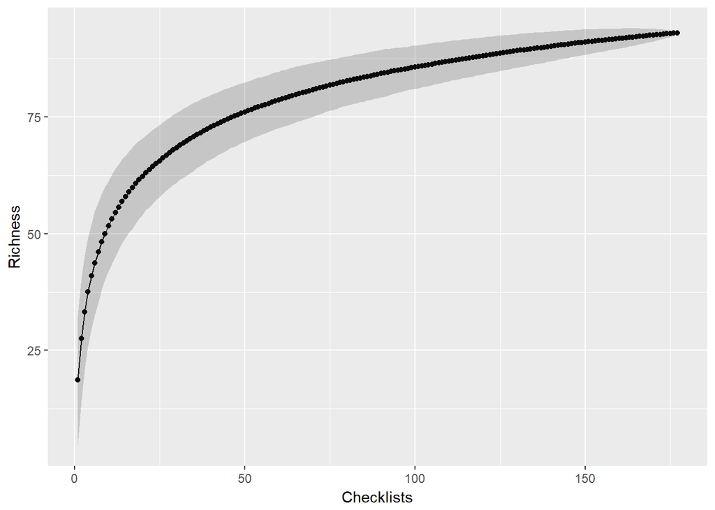

```r
# specaccum function from vegan
BV_acc <- specaccum(BV_species, method = "random", permutations = 1000)

# make it a dataframe
BV_acc.data <- data.frame(Checklists = BV_acc$sites, Richness = BV_acc$richness,
    SD = BV_acc$sd)

BV_acc.data$specpool <- specpool(BV_species)[, 2]
BV_acc.data$cumpercent.estimated <- (BV_acc.data$Richness/BV_acc.data$specpool) *
    100

ggplot(BV_acc.data, aes(x = Checklists, y = Richness)) + geom_point() + geom_line() +
    geom_ribbon(aes(x = Checklists, ymin = (Richness - 2 * SD), ymax = (Richness +
        2 * SD)), alpha = 0.2)
```

#### Step 2.1.3: Calculate the number of checklists necessary to reach percentage thresholds (70%, 80%, 90%)

```r
# this dataframe represents the minimum number of checklists needed to reach
# 70% of the estimated species richness at a particular site
seventy_threshold <- data.frame(BV_acc.data %>% filter(cumpercent.estimated >=
    70) %>% slice(which.min(cumpercent.estimated)))[c(1)]
seventy_threshold$threshold <- "70%"

# same as above, but for 80% threshold
eighty_threshold <- data.frame(BV_acc.data %>% filter(cumpercent.estimated >=
    80) %>% slice(which.min(cumpercent.estimated)))[c(1)]
eighty_threshold$threshold <- "80%"

# same as above, but for 90% threshold
ninety_threshold <- data.frame(BV_acc.data %>% filter(cumpercent.estimated >=
    90) %>% slice(which.min(cumpercent.estimated)))[c(1)]
ninety_threshold$threshold <- "90%"

# combine the three dataframes created above
SPECIES_RICHNESS_THRESHOLDS.all <- rbind(seventy_threshold, eighty_threshold,
    ninety_threshold)
```

Look at the minimum number of checklists to reach the necessary thresholds

```r
head(SPECIES_RICHNESS_THRESHOLDS.all)
```

```
##   Checklists threshold
## 1         34       70%
## 2         67       80%
## 3        141       90%
```

#### Step 2.1.4 Repeat the analysis, but eliminate the species which occured on <= 5% of checklists

This is easily accomplished by substituting the dataframe which is **analysis_data.95** in for the **analysis_data.all** in the first line, above. The code has been excluded here, but the results shown below.

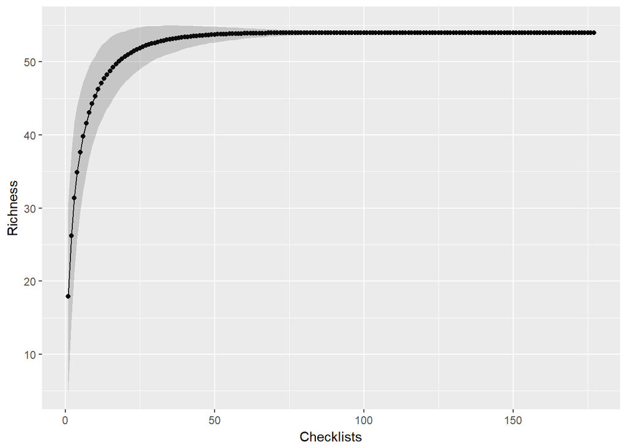

```
##   Checklists threshold
## 1          6       70%
## 2          9       80%
## 3         15       90%
```

### Step 2.2: Community Composition (Bray-curtis similarity index)

#### Step 2.2.1: Using the autosimi function, from the CommEcol package

This function has been slightly modified to allow for replacement and to create a standard deviation of the permutations

```r
autosimi <- function(comm, method = "bray", binary = FALSE, log.transf = FALSE,
    simi = TRUE, permutations = 1000) {

    n.samp <- nrow(comm)
    spp <- ncol(comm)
    size <- n.samp
    sizes <- 1:size

    resu.m <- matrix(NA, size, permutations)

    for (i in 1:permutations) {
        for (j in sizes) {
            if (j == 1) {
                pair <- comm[sample(1:n.samp, 2), ]
            }
            if (j > 1) {
                temp <- comm[sample(1:n.samp, j * 2, replace = TRUE), ]
                temp1 <- temp[1:j, ]
                temp2 <- temp[(j + 1):(j * 2), ]
                temp1 <- colSums(temp1)
                temp2 <- colSums(temp2)
                pair <- rbind(temp1, temp2)
            }

            if (binary == TRUE)
                {
                  pair <- ifelse(pair > 0, 1, 0)
                }  # close if binary
            if (binary == FALSE & log.transf == TRUE) {
                pair <- log(pair + 1)
            }
            if (binary == TRUE & log.transf == TRUE) {
                stop("You can not log-transform presence/absence data")
            }

            if (simi == TRUE) {
                resu.m[j, i] <- as.numeric(1 - vegdist(pair, method, binary))
            }
            if (simi == FALSE) {
                resu.m[j, i] <- as.numeric(vegdist(pair, method, binary))
            }
        }  #close for j
    }  # close for i

    mean.perm <- rowMeans(resu.m)
    sd.perm <- apply(resu.m, 1, sd)
    resu <- data.frame(sizes, mean.perm, sd.perm)
    indexes <- c("manhattan", "euclidean", "canberra", "bray", "kulczynski",
        "jaccard", "gower", "altGower", "morisita", "horn", "mountford", "raup",
        "binomial", "chao")
    colnames(resu) <- c("sample.size", indexes[pmatch(method, indexes)], "sd")
    return(resu)
}
```

#### Step 2.2.2: Preparing data for analysis

This is done in the same way as above.

```r
# select the necessary columns
BV_species <- analysis_data.all %>% select(COMMON_NAME, OBSERVATION_COUNT, SAMPLING_EVENT_IDENTIFIER)

# spread the columns to a matrix form
BV_species <- dcast(BV_species, SAMPLING_EVENT_IDENTIFIER ~ COMMON_NAME, fun.aggregate = mean,
    value.var = "OBSERVATION_COUNT")

# remove NaN and replacing with 0
BV_species <- as.data.frame(lapply(BV_species, function(y) gsub("NaN", "0",
    y)))

# subset the checklists to make row names
BV_species_row.names <- BV_species$SAMPLING_EVENT_IDENTIFIER
row.names(BV_species) <- BV_species_row.names
BV_species$SAMPLING_EVENT_IDENTIFIER <- NULL


# make the entire data frame numeric for analysis sake
asNumeric <- function(x) as.numeric(as.character(x))
factorsNumeric <- function(d) modifyList(d, lapply(d[, sapply(d, is.factor)],
    asNumeric))
BV_species <- factorsNumeric(BV_species)
```

#### Step 2.2.3: Using the autosimi function

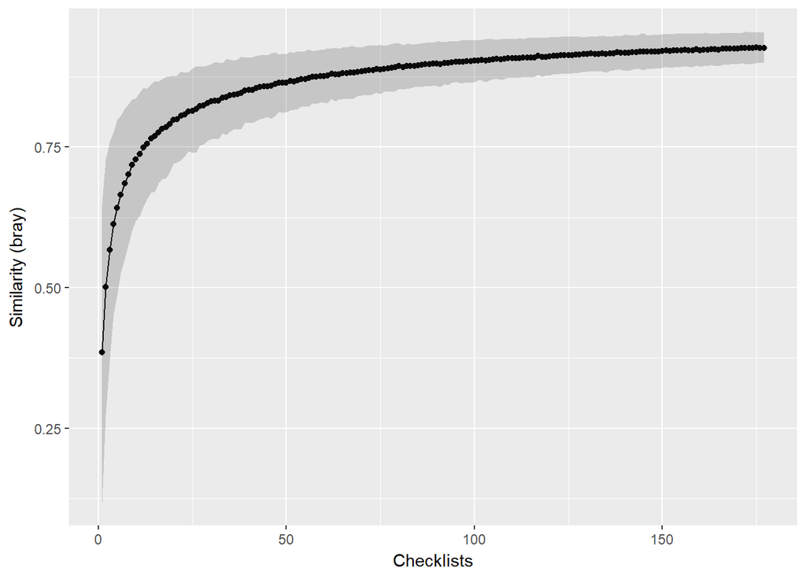

```r
similarity_BV <- autosimi(BV_species)

similarity_BV$total <- tail(similarity_BV$bray, n = 1)
similarity_BV$cumpercent.observed <- (similarity_BV$bray/similarity_BV$total) *
    100

# plot it
ggplot(similarity_BV, aes(x = sample.size, y = bray)) + geom_point() + geom_line() +
    geom_ribbon(aes(x = sample.size, ymin = (bray - 2 * sd), ymax = (bray +
        2 * sd)), alpha = 0.2) + xlab("Checklists") + ylab("Similarity (bray)")
```

#### Step 2.2.4: Calculating the number of checklists necessary to reach percentage thresholds (70%, 80%, 90%)

```r
# this dataframe represents the minimum number of checklists needed to reach
# 70% of the estimated species richness at a particular site
seventy_threshold <- data.frame(similarity_BV %>% filter(cumpercent.observed >=
    70) %>% slice(which.min(cumpercent.observed)))[c(1)]
seventy_threshold$threshold <- "70%"

# same as above, but for 80% threshold
eighty_threshold <- data.frame(similarity_BV %>% filter(cumpercent.observed >=
    80) %>% slice(which.min(cumpercent.observed)))[c(1)]
eighty_threshold$threshold <- "80%"

# same as above, but for 90% threshold
ninety_threshold <- data.frame(similarity_BV %>% filter(cumpercent.observed >=
    90) %>% slice(which.min(cumpercent.observed)))[c(1)]
ninety_threshold$threshold <- "90%"

# combine the three dataframes created above
COMMUNITY_COMPOSITION_THRESHOLDS.all <- rbind(seventy_threshold, eighty_threshold,
    ninety_threshold)
```

Look at the minimum number of checklists to reach the necessary thresholds

```r
head(COMMUNITY_COMPOSITION_THRESHOLDS.all)
```

```
##   sample.size threshold
## 1           6       70%
## 2          12       80%
## 3          33       90%
```

#### Step 2.2.5 As above, repeat the analysis, but eliminate the species which occured on <= 5% of checklists

Again, the code is not shown.

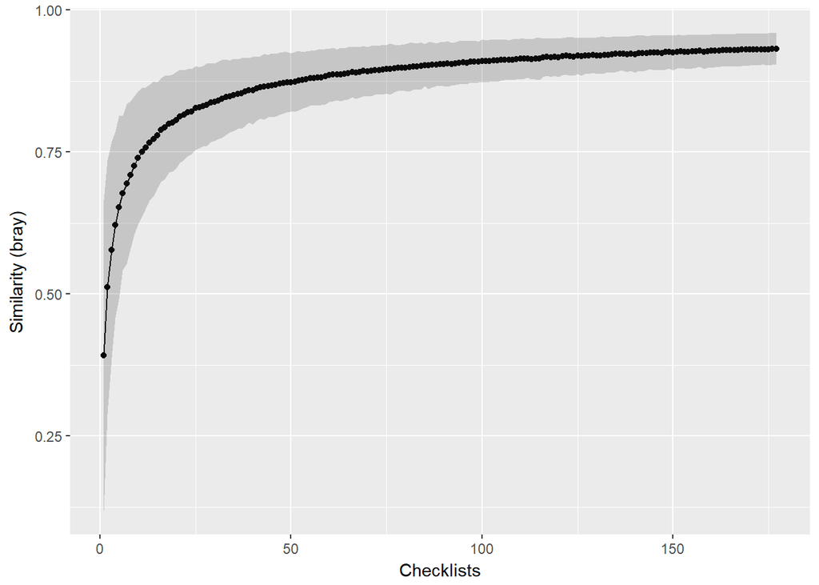

```
##   sample.size threshold
## 1           5       70%
## 2          11       80%
## 3          31       90%
```

### Step 2.3: Shannon Diversity

#### Step 2.3.1: This is a function to run a bootstrap on the Shannon Diversity

```r
select_hotspot <- function(hotspot, data) {
    hotspot_data <- data %>% filter(LOCALITY_ID == hotspot) %>% select(COMMON_NAME,
        OBSERVATION_COUNT, SAMPLING_EVENT_IDENTIFIER)
    return(hotspot_data)
}

calculate_hotspot_diversity <- function(n, hotspot_data, quiet = T) {
    sampled_hotspots <- sample(unique(as.character(hotspot_data$SAMPLING_EVENT_IDENTIFIER)),
        n, replace = T)
    sampled_hotspot_diversity <- hotspot_data %>% filter(SAMPLING_EVENT_IDENTIFIER %in%
        sampled_hotspots) %>% group_by(COMMON_NAME) %>% summarise(mean_count = mean(OBSERVATION_COUNT)) %>%
        select(mean_count) %>% summarise(diversity = vegan::diversity(mean_count)) %>%
        mutate(number_checklists = n)
    if (!quiet) {
        message(paste0("Boostrap ", n))
    }
    return(sampled_hotspot_diversity)
}

bootstrap_checklist_once <- function(hotspot, data) {
    hotspot_data <- select_hotspot(hotspot, data)
    checklist_n <- length(unique(as.character(hotspot_data$SAMPLING_EVENT_IDENTIFIER)))
    boostrapped_diversity <- lapply(X = 1:checklist_n, FUN = calculate_hotspot_diversity,
        hotspot_data)
    return(rbindlist(boostrapped_diversity))
}

bootstrap_hotspot_diversity <- function(hotspot, data, nboot = 10, plot = T,
    quiet = T) {
    if (!hotspot %in% data$LOCALITY_ID) {
        stop(paste0(hotspot, " hotspot is not in the data"))
    }
    message(paste0("Analysing the ", hotspot, " hotspot"))

    bootstrap_results <- rbindlist(replicate(n = nboot, bootstrap_checklist_once(hotspot,
        data), simplify = F))

    if (plot) {
        bootstrap_summary <- bootstrap_results %>% group_by(number_checklists) %>%
            summarise(mean = mean(diversity), sd = sd(diversity), cv = sd/mean,
                upper_95 = quantile(diversity, 0.975), lower_95 = quantile(diversity,
                  0.025))

        plt <- ggplot(bootstrap_summary, aes(x = number_checklists)) + geom_point(aes(y = mean)) +
            geom_line(aes(y = mean)) + geom_ribbon(aes(ymin = (lower_95), ymax = (upper_95)),
            alpha = 0.2) + ggtitle(hotspot) + xlab("Checklists") + ylab("Diversity")
        print(plt)
        invisible(bootstrap_summary)
    } else {
        return(bootstrap_results)
    }
}
```

#### Step 2.3.2: Use the function to calculate the diversity

```
## Analysing the L508074 hotspot
```

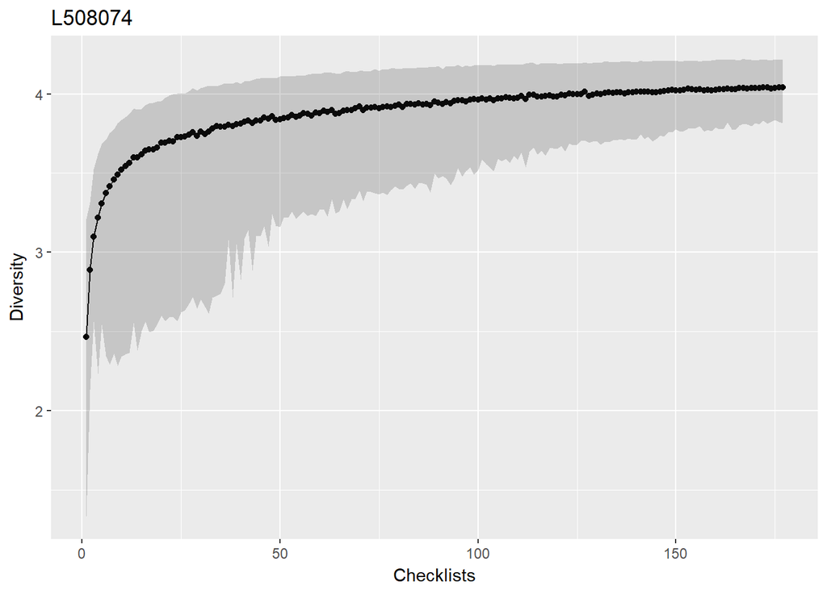

```r
BV_diversity <- bootstrap_hotspot_diversity("L508074", analysis_data.all, nboot = 1000,
    plot = T)
```

```r
BV_diversity$total <- tail(BV_diversity$mean, n = 1)
BV_diversity$cumpercent.observed <- (BV_diversity$mean/BV_diversity$total) *
    100
```

#### Step 2.3.3: Calculate the number of checklists necessary to reach percentage thresholds (70%, 80%, 90%)

```r
# this dataframe represents the minimum number of checklists needed to reach
# 70% of the estimated species richness at a particular site
seventy_threshold <- data.frame(BV_diversity %>% filter(cumpercent.observed >=
    70) %>% slice(which.min(cumpercent.observed)))[c(1)]
seventy_threshold$threshold <- "70%"

# same as above, but for 80% threshold
eighty_threshold <- data.frame(BV_diversity %>% filter(cumpercent.observed >=
    80) %>% slice(which.min(cumpercent.observed)))[c(1)]
eighty_threshold$threshold <- "80%"

# same as above, but for 90% threshold
ninety_threshold <- data.frame(BV_diversity %>% filter(cumpercent.observed >=
    90) %>% slice(which.min(cumpercent.observed)))[c(1)]
ninety_threshold$threshold <- "90%"

# combine the three dataframes created above
SPECIES_DIVERSITY_THRESHOLDS.all <- rbind(seventy_threshold, eighty_threshold,
    ninety_threshold)
```

Look at the minimum number of checklists to reach the necessary thresholds

```r
head(SPECIES_DIVERSITY_THRESHOLDS.all)
```

```
##   number_checklists threshold
## 1                 2       70%
## 2                 5       80%
## 3                16       90%
```

#### Step 2.3.4 Repeat the analysis, but eliminate the species which occured on <= 5% of checklists

Again, the code is not shown.

```
## Analysing the L508074 hotspot
```

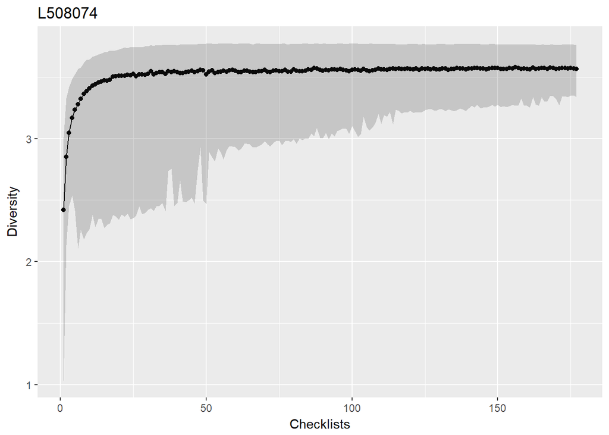

```
##   number_checklists threshold
## 1                 2       70%
## 2                 3       80%
## 3                 5       90%
```